# Utility Non-Payment Risk & Consequence Model

Predicting electricity billing risk from real smart-meter data, and modeling what actually happens next

Hugo Garcia Moreno

August 21, 2026

## 1. What this project actually does

Most student “predict the bill” projects stop at forecasting a dollar amount. This one chains four pieces together:

```
[Real NYC weather] --> [Degree-day regression] --> [Predicted monthly bill]
                                                            v
[Real SGCC usage data] --> [Logistic reg. + tree] --> [ML risk tier] --> [Markov chain risk engine] --> [P(disconnected), E[months to disconnect]]
                                                                                   ^
                                                                    [HEFPA-cited consequence cascade]
```

1. **Statistically**, can the *pattern* of a household’s or business’s electricity usage (the shape of it over time, separate from the dollar amount) predict whether they’re at elevated risk of a serious non-payment or billing problem? (Section 4.)
2. **Physically**, how does a local weather record turn into a predicted monthly bill, and what does an actual heatwave do to it? (Section 5.)
3. **Stochastically**, if a bill’s status is a state (current, late, severely late, disconnected), how does it move between those states over time, and how long does that take, as a function of risk tier and bill-to-income stress? (Section 6, a discrete-time Markov chain.)
4. **As a matter of policy**, once a bill actually goes unpaid, what happens next, in calendar days and dollars? And where can available protections interrupt that sequence? (Section 7.)

Piece 1 is a machine-learning pipeline trained on individually labeled utility data. Piece 2 is a physical model (the same degree-day method utilities use for weather-normalized billing) run on historical NYC temperatures. Piece 3 is linear algebra, but where no public dataset exists to fit its inputs, those inputs are **stated modeling assumptions, not measurements**, and the report says so at the point each one is introduced. Piece 4 is a small rules engine built from actual New York State utility regulation, with each rule cited. **These are kept in separate scripts on purpose.** A statistical risk score, an assumed transition probability, and a legal deadline are three different kinds of claim, and blending them into one number would hide the distinctions a reader needs in order to trust or challenge any of this.

## 2. Data

```r
dt <- readRDS(file.path(out_dir, "clean_wide.rds"))
features <- readRDS(file.path(out_dir, "features.rds"))
flag_tab <- table(dt$FLAG)
```

The consumption data is the public **State Grid Corporation of China (SGCC) electricity-theft dataset**: 33,840 real electricity customers, daily meter readings from **2014-01-01 to 2016-10-31**, each labeled `FLAG = 1` if the utility confirmed the account for electricity theft/billing fraud. It was released alongside a peer-reviewed paper:

> Zheng, Z., Yang, Y., Niu, X., Dai, H.-N., & Zhou, Y. (2018). “Wide and Deep Convolutional Neural Networks for Electricity-Theft Detection to Secure Smart Grids.” *IEEE Transactions on Industrial Informatics*, 14(4), 1606-1615. https://doi.org/10.1109/TII.2017.2785963

Class balance: **30225** normal accounts vs. **3615** flagged (10.7%). That imbalance is realistic for this kind of problem, and it drives the modeling choices in Section 4.

## 3. From a raw meter reading to a feature table

A theft or non-payment signal doesn’t live in any single day’s kWh reading. It lives in the *shape* of usage over time. Working straight off the 1034-day-wide raw matrix, I engineered 14 per-customer statistical features: overall level and volatility, the share of missing or exactly-zero reads, the longest gap in reporting, a linear trend over the whole series, weekday/weekend and winter/summer ratios, and year-over-year drift.

**A real data-cleaning problem showed up immediately:** a handful of accounts in this “residential” file report usage in the thousands of kWh/day (almost certainly commercial/industrial meters mixed into the file). Naive ratio features (`weekend usage / weekday usage`, `winter / summer`, `2016 usage / 2014 usage`) blew up toward infinity whenever one of these accounts had a near-zero reading in the denominator period. For roughly 1% of accounts this wasn’t a rounding error, it was values in the *thousands*. The fix was to switch these three features from a raw ratio to a **log-ratio** (`log1p(period A) - log1p(period B)`): same “which period was higher, by roughly what multiple” information, but bounded and stable as usage approaches zero. `range_ratio` was left as a plain ratio but winsorized at the 1st/99th percentile. This is the kind of thing that looks like a footnote but actually determines whether a model is measuring signal or measuring an outlier. See `scripts/02_feature_engineering.R` for the full before/after.

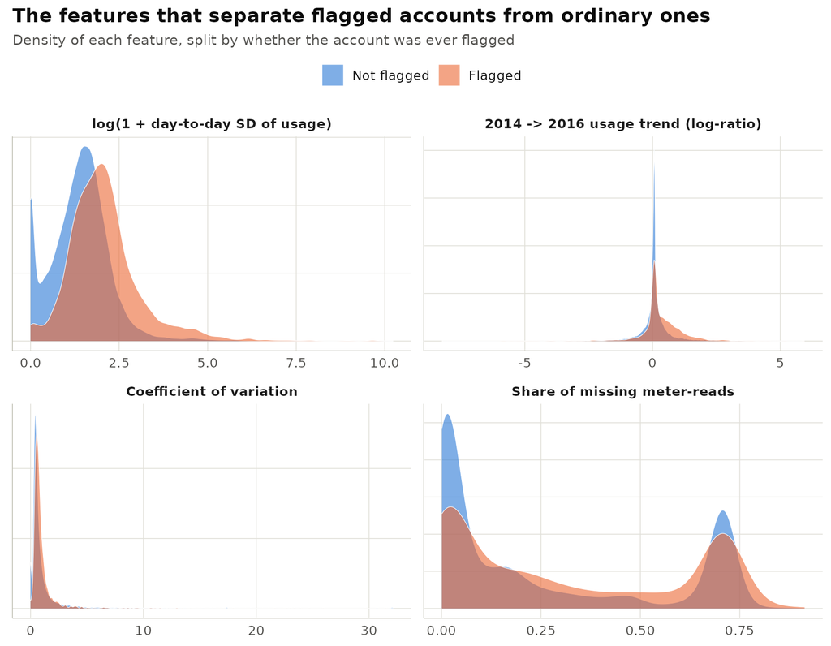

Distributions of four of the strongest features, split by outcome.

```r
include_graphics(file.path(out_dir, "plots", "feature_distributions.png"))
```

Flagged accounts show up as (a) noticeably higher day-to-day volatility once you control for scale, (b) more missing/zero reads and longer reporting gaps, and (c) a more pronounced upward drift in usage from 2014 to 2016, all patterns that make physical sense for a tampered meter that is used more freely over time and reported on less reliably.

## 4. Modeling non-payment/theft risk

```r
mr <- readRDS(file.path(out_dir, "model_results.rds"))
```

Two models were trained on a 70/30 stratified split (10,136 held-out test customers): an interpretable **logistic regression** and a **decision tree** (`rpart`), both trained cost-sensitively to counter the ~89%/11% class imbalance: observations were weighted (logistic) or the tree’s split loss was penalized (decision tree) so that missing a true flagged account costs roughly 8.4x more than a false alarm, matching the actual class imbalance.

**Why not just report accuracy?** Because a model that predicts “not at risk” for every single customer would already score **89.3%** accuracy here, while being completely useless, since it would flag zero of the real theft/non-payment cases. This is precisely the scenario precision/recall and ROC/AUC exist for.

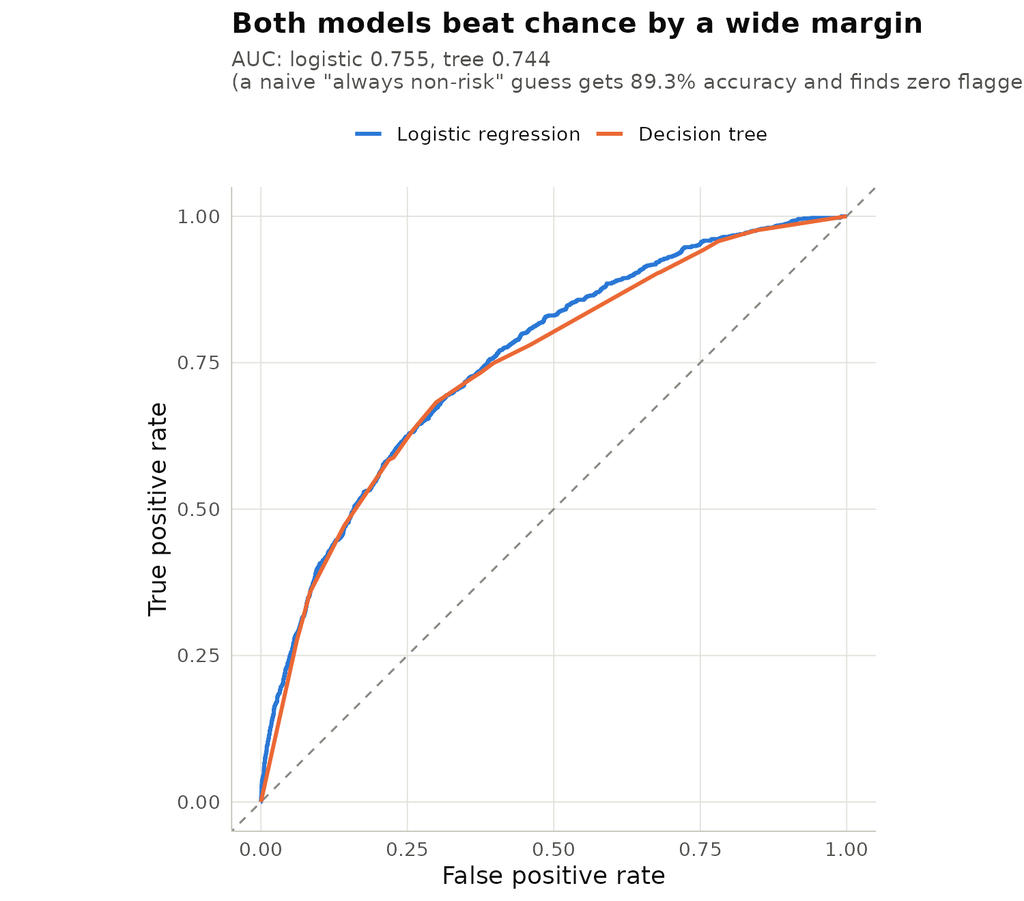

ROC curves for both models against the no-skill diagonal.

```r
include_graphics(file.path(out_dir, "plots", "roc_curves.png"))
```

Both models land at a respectable, believable **AUC around 0.75**, consistent with published results on this dataset using classical (non-deep-learning) features, and *not* suspiciously close to 1.0, which would be a red flag for leakage.

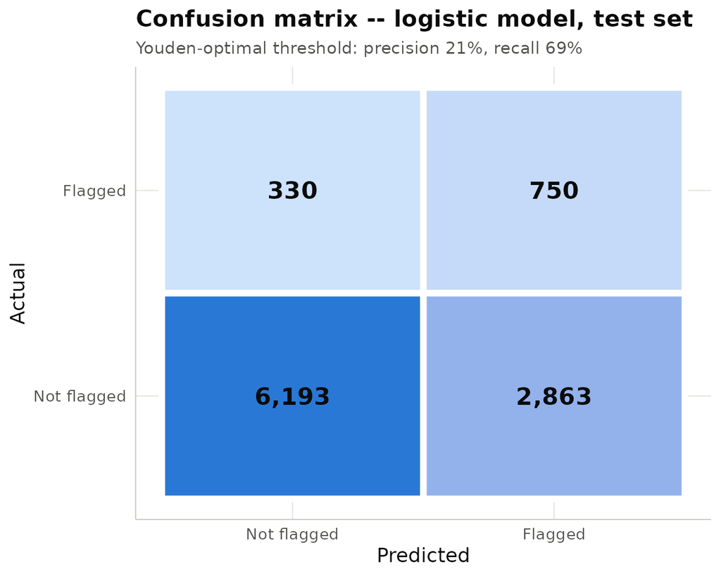

Confusion matrix at the Youden-optimal operating threshold.

```r
include_graphics(file.path(out_dir, "plots", "confusion_matrix.png"))
```

At the Youden-optimal threshold the logistic model catches **69%** of true flagged accounts (recall) while roughly **21%** of everything it flags turns out to be a genuine positive (precision). That precision looks low in isolation, but it’s the right trade for this use case: a flag here should trigger low-cost proactive outreach (a payment-plan offer, a HEAP screening call) long before anything resembling an accusation, so the cost of a false positive is small and the cost of a false negative (missing a household headed for disconnection) is not.

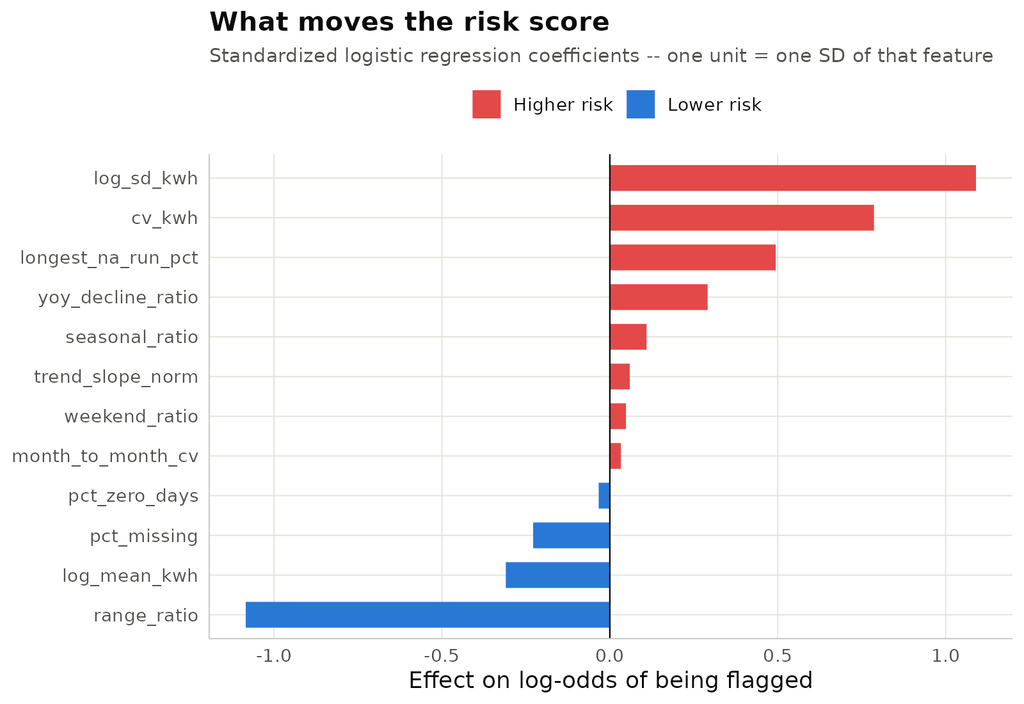

Standardized logistic regression coefficients.

```r
include_graphics(file.path(out_dir, "plots", "coefficients.png"))
```

The coefficients read the same story the density plots showed: usage *volatility* (`log_sd_kwh`, `cv_kwh`) and a longer *history of missing reads* are the strongest positive signals; a wide, stable, well-metered usage range (`range_ratio`) is the strongest protective signal.

## 5. Forecasting the bill from real weather

```r
wthr <- readRDS(file.path(out_dir, "weather_results.rds"))
```

Everything above works from usage *shape*, not the bill amount. This section adds the missing piece: a real physical forecast of the bill itself, using the standard utility-industry **degree-day method**: electricity demand for heating and cooling scales with how far a day’s temperature sits from a 65°F “balance point,” not with temperature directly.

**The temperature data is real**: daily NYC-area records for all of 2015 (chosen to line up with the SGCC data’s own 2014-2016 window), from the public `zonination/weather-us` historical weather archive. **The dollar calibration is externally anchored, not invented**: the model’s cooling-season sensitivity is set so that a full Jun-Sep cooling season matches NEADA’s published 2026 Mid-Atlantic average summer cooling bill of **$790**, a real, cited, independent number the model is checked against, not fit to. Heating sensitivity is set at 40% of the cooling rate, a stated assumption (Northeast homes lean on gas heat, so the *electric* bill’s heating response is real but smaller) rather than a second anchored figure.

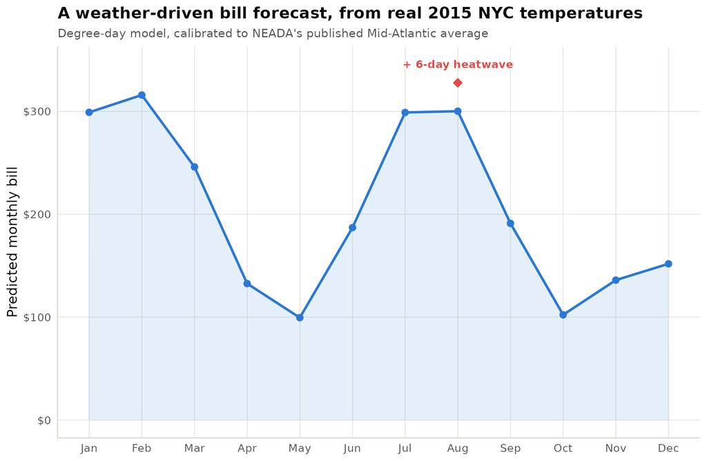

A full year of predicted bills from real NYC temperatures.

```r
include_graphics(file.path(out_dir, "plots", "weather_bill_forecast.png"))
```

### The weather-shock simulator

Real NYC heatwaves run 5-7 days with daily highs near 95-100°F. Swapping six days of the model’s hottest month (August) for a representative heatwave day (mean temp 90°F) and recomputing that month’s cooling degree-days raises the predicted bill from **$300.13** to **$327.74**, a **9.2%** jump from six unusual days. Section 6 carries this shock through to its actual consequence: the same dollar increase means very different things at different incomes.

## 6. A stochastic risk engine: the bill’s lifecycle as a Markov chain

```r
markov <- readRDS(file.path(out_dir, "markov_results.rds"))
```

Sections 4-5 produce two numbers: an ML risk tier and a predicted bill. This section is what actually *uses* both of them together, by modeling a bill’s status explicitly as a state that moves over time. Four states, one month per step, aligned with the HEFPA timeline in Section 7 (a ~35-day notice-to-disconnection window is, for a monthly model, “about one step”):

**Current → Late (1-30 days) → Severe (31-60+ days, disconnection-eligible) → Disconnected** (absorbing in this model).

Two different kinds of input set the transition probabilities, and this report is explicit about which is which:

- **The `Current → Late` probability is grounded in the fitted classifier**: it’s set by the same Low / Elevated / High risk tier from Section 4’s logistic model.
- **Once an account is late, whether it cures or progresses is set by a stated, illustrative function of “stress index”** (predicted bill ÷ assumed monthly income): rising stress lowers the cure probability and raises the progress probability, clipped to valid probabilities. **This function is a modeling assumption, not a measurement**: no public dataset labels individual month-by-month delinquency transitions, so there is nothing to fit it to. Saying so here, rather than presenting illustrative numbers as empirical ones, is the entire point of keeping this section separate from Section 4.

All of the matrix algebra below (n-step transition matrices, the fundamental matrix, expected time to absorption) is implemented directly with base R linear algebra, `solve()` on `I - Q`, rather than a package call. I wanted this section to show the mechanics, not hide them behind a library.

```r
kable(round(markov$illustrative_matrix, 3), caption = "Example transition matrix: Elevated risk, near-HEAP-eligible income, typical August bill")
```

Example transition matrix: Elevated risk, near-HEAP-eligible income, typical August bill

|  | Current | Late | Severe | Disconnected |
| --- | --- | --- | --- | --- |
| Current | 0.880 | 0.12 | 0.000 | 0.000 |
| Late | 0.483 | 0.17 | 0.347 | 0.000 |
| Severe | 0.203 | 0.00 | 0.553 | 0.243 |
| Disconnected | 0.000 | 0.00 | 0.000 | 1.000 |

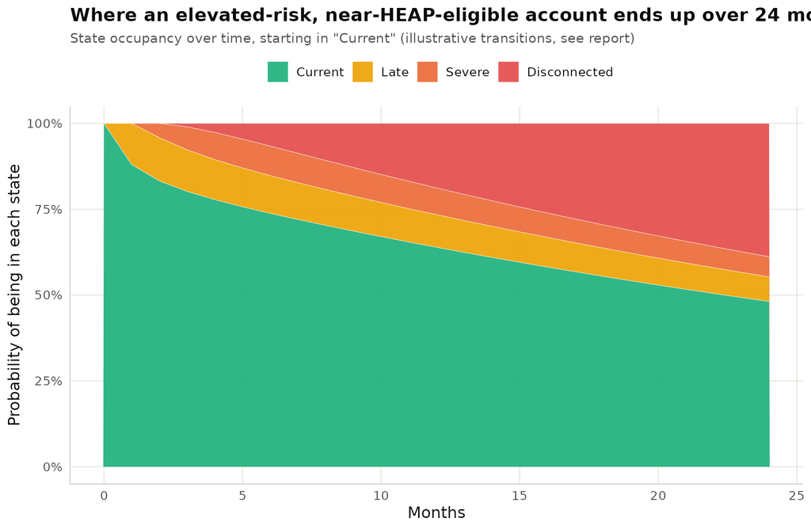

State occupancy over 24 months for that example.

```r
include_graphics(file.path(out_dir, "plots", "markov_trajectory.png"))
```

### Where the weather shock and income actually compound

```r
kable(markov$scenario_results[, .(Tier = tier, Income = income_label, Bill = bill_label,
                                    `Stress index` = stress_index,
                                    `E[months to disconnect]` = expected_months_to_disconnect,
                                    `P(disconnect, 12mo)` = scales::percent(p_disconnected_12mo, accuracy = 0.1))])
```

| Tier | Income | Bill | Stress index | E[months to disconnect] | P(disconnect, 12mo) |
| --- | --- | --- | --- | --- | --- |
| Elevated | Moderate income ($3,000/mo) | August + heatwave | 0.1092 | 84.6 | 10.4% |
| Elevated | Moderate income ($3,000/mo) | Typical August bill | 0.1000 | 95.1 | 9.3% |
| Elevated | Near HEAP-eligible ($1,800/mo) | August + heatwave | 0.1821 | 40.2 | 21.4% |
| Elevated | Near HEAP-eligible ($1,800/mo) | Typical August bill | 0.1667 | 46.0 | 18.8% |
| High | Moderate income ($3,000/mo) | August + heatwave | 0.1092 | 45.1 | 19.6% |
| High | Moderate income ($3,000/mo) | Typical August bill | 0.1000 | 50.5 | 17.6% |
| High | Near HEAP-eligible ($1,800/mo) | August + heatwave | 0.1821 | 22.0 | 38.5% |
| High | Near HEAP-eligible ($1,800/mo) | Typical August bill | 0.1667 | 25.1 | 34.2% |
| Low | Moderate income ($3,000/mo) | August + heatwave | 0.1092 | 291.6 | 3.0% |
| Low | Moderate income ($3,000/mo) | Typical August bill | 0.1000 | 328.9 | 2.6% |
| Low | Near HEAP-eligible ($1,800/mo) | August + heatwave | 0.1821 | 135.4 | 6.3% |
| Low | Near HEAP-eligible ($1,800/mo) | Typical August bill | 0.1667 | 155.8 | 5.5% |

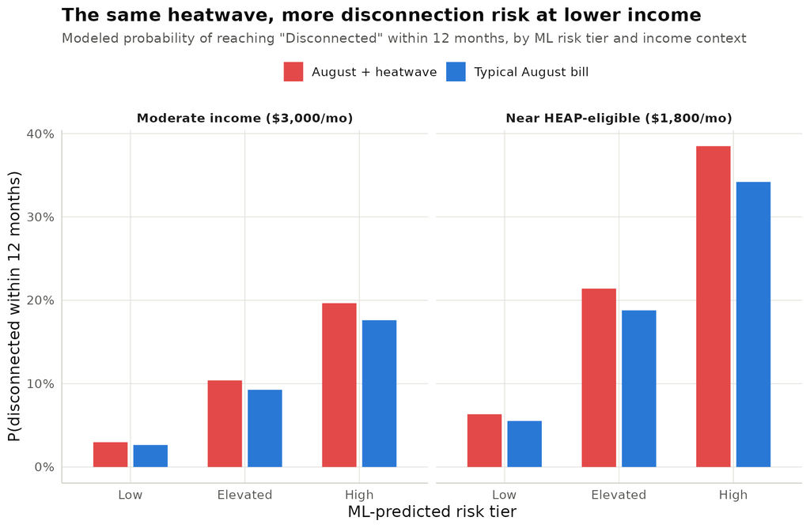

The same 6-day heatwave, compared across risk tier and income.

```r
include_graphics(file.path(out_dir, "plots", "markov_scenarios.png"))
```

Two things stand out. First, **risk tier alone spans a huge range**: at moderate income, a Low-risk account’s expected time to disconnection is measured in decades (27 years, so effectively not a near-term concern), while a High-risk account at the same income is measured in years. Second, and this is what the weather-shock simulator was built to show: **the identical 6-day heatwave moves the 12-month disconnection probability by a larger absolute amount for the near-HEAP-eligible household than for the moderate-income one, in every risk tier.** The same weather event hits different households differently. Climate-economics research describes this equity mechanism; here it comes out of a fully specified model a reader can inspect.

### How much do the stated assumptions matter? A sensitivity analysis

The weakness of this chain, stated above, is that the transition probability functions for already-late accounts are assumptions rather than fitted values. The right response is to measure how much that matters: if the conclusions swung wildly whenever an assumed coefficient moved a little, the model would be decoration. So `09_sensitivity.R` runs two checks on the reference scenario (Elevated tier, near-HEAP-eligible income, typical August bill).

```r
sens <- readRDS(file.path(out_dir, "sensitivity_results.rds"))
```

**One at a time.** Each assumed parameter is moved ±20% from its stated value while the rest stay put:

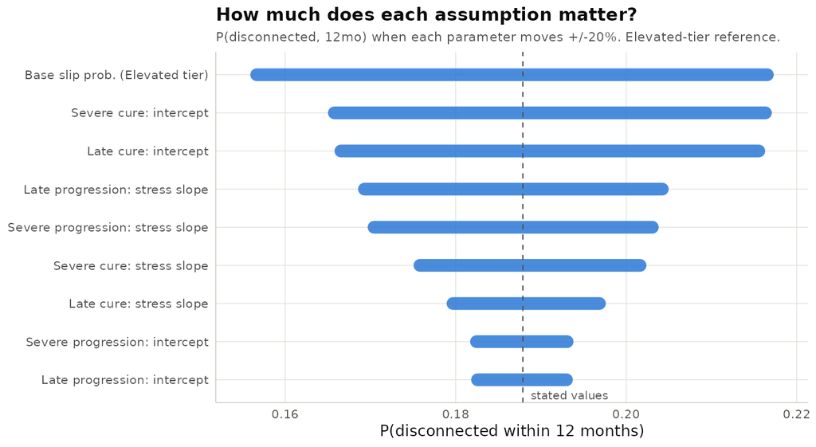

Tornado analysis: each assumed parameter perturbed ±20%, one at a time.

```r
include_graphics(file.path(out_dir, "plots", "sensitivity_tornado.png"))
```

No single ±20% perturbation moves the 12-month disconnection probability by more than about ±0.03 around its stated-value run of 0.188. The most influential single parameter turns out to be the Elevated tier’s base slip probability, and that is the one input anchored to the fitted classifier’s operating thresholds rather than assumed. The model leans hardest on its best-grounded number, which is the right way around.

**All at once.** A joint Monte Carlo draws every assumed parameter simultaneously from independent ±20% ranges (1,932 valid draws of 2,000):

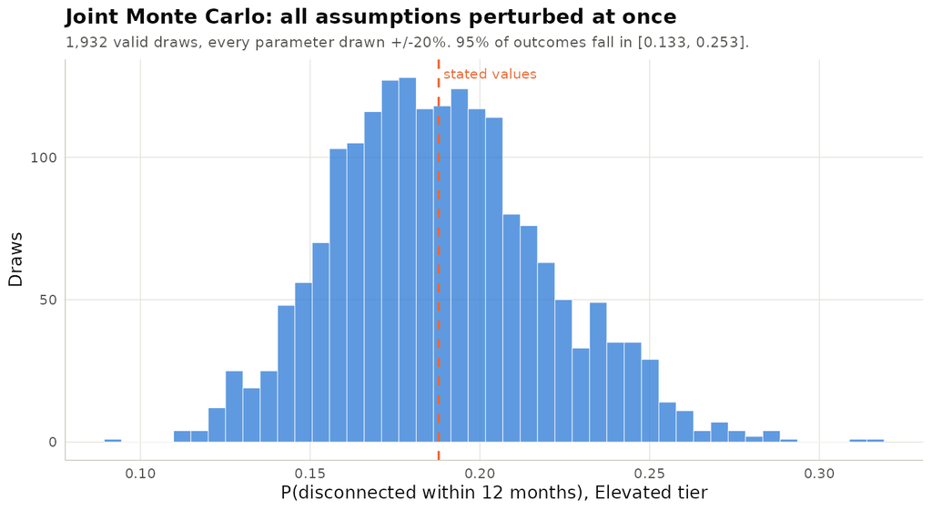

Joint Monte Carlo: every assumed parameter drawn from a ±20% range simultaneously.

```r
include_graphics(file.path(out_dir, "plots", "sensitivity_montecarlo.png"))
```

Even with everything perturbed at once, 95% of outcomes stay between 0.133 and 0.253. The headline stays “roughly a one-in-five chance within a year” instead of flipping to negligible or near-certain. And the qualitative claim the project rests on, High risk above Elevated above Low at identical income and bill, holds in **100.0% of joint draws**. The exact probabilities inherit the assumptions’ uncertainty. The ordering and the order of magnitude do not.

## 7. What happens after a bill actually goes unpaid

This section is **not** a statistical model, on purpose. Section 4 estimates a probability from usage data. This section states, as accurately as I could research it, what New York State utility regulation requires once a bill goes unpaid. Mixing the two, letting a risk score imply a legal timeline, would be a real error, so they’re built and presented separately.

```r
cons <- readRDS(file.path(out_dir, "consequences.rds"))
kable(cons$cascade[, .(`Day (after due date)` = day_offset, Category = category, Event = event)])
```

[output not shown]

**Primary sources:**

- NY Dept. of Public Service, *“Your Rights as a Residential Gas, Electric or Steam Customer Under HEFPA”* – https://dps.ny.gov/your-rights-residential-gas-electric-or-steam-customer-under-hefpa (15-day disconnection notice, 1.5%/month late fee, Nov 1-Apr 15 cold-weather protections, deferred payment agreement terms, security deposit rules)
- Consumer Financial Protection Bureau, on utility bills and credit reports – https://www.consumerfinance.gov/ask-cfpb/does-my-history-of-paying-utility-bills-like-telephone-cable-electricity-or-water-go-in-my-credit-report-en-1817/ (utilities generally do **not** report routine payment history to the major credit bureaus; a credit-report impact typically requires the debt to be referred to a third-party collection agency first)
- UtilityExplained.com, reconnection fee ranges (a market survey, not a regulatory figure; reconnection fees are set by each utility’s own tariff)
- NY OTDA HEAP guidelines (income tiers / benefit caps shown are **illustrative** and republished yearly. Verify current figures at mybenefits.ny.gov before relying on them for a real decision)

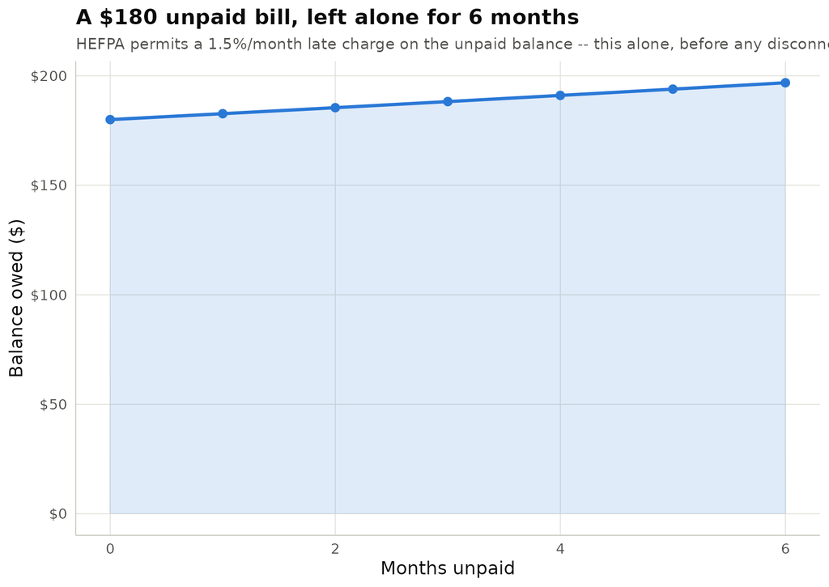

HEFPA’s 1.5%/month late charge, compounding on the outstanding balance.

```r
include_graphics(file.path(out_dir, "plots", "late_fee_projection.png"))
```

The most important fact in this section, and one a usage-based ML model could never tell you: **routine non-payment does not, by itself, damage a credit score.** New York utilities generally don’t report ordinary payment history to the major bureaus at all. The credit consequence only attaches at a specific, later, avoidable step: referral to a third-party collection agency. That is the kind of fact that should reach a household *before* day 35, not after.

### Turning a risk score into a recommended action

```r
kable(cons$examples[, .(Scenario = scenario, `Risk score` = round(risk_prob, 3), Tier = tier, `Recommended action` = action)])
```

| Scenario | Risk score | Tier | Recommended action |
| --- | --- | --- | --- |
| Low risk | 0.050 | Low | No action beyond a normal reminder. |
| Elevated risk | 0.493 | Elevated | Proactive outreach recommended: payment plan (DPA) offer + HEAP screening before day 20. |
| High risk | 0.838 | High | Priority outreach before Final Termination Notice window; DPA + HEAP screening + cold-weather protection check. |

## 8. Limitations

- **The label is a proxy.** `FLAG` marks confirmed electricity theft, not garden-variety late payment. The overlap is real (both are forms of revenue loss the utility responds to) but not exact, and I’m not claiming otherwise.
- **The consequence figures are New York-specific and time-bound.** HEFPA is a New York State law; other states have different (sometimes much weaker) protections. The HEAP numbers are one program-year’s guidance and change annually.
- **Reconnection fees are not a single number.** They’re set utility-by-utility by tariff; the range shown is a market survey, not a rule.
- **~26% of readings in the raw data are missing**, and missingness itself turned out to be predictive (see Section 3). Some of what the model learns is really “how well-monitored is this account,” not purely “how much electricity did it use.”
- **AUC ~0.75 is good, not great.** There’s real room for improvement, for example neighborhood or weather covariates, or the CNN approach from the original paper. That open room is part of why this is a project and not a solved problem.
- **The weather module and the usage-risk model are not paired to the same customers.** The SGCC data is Chinese and unlabeled by location; the weather data is NYC history. They’re joined only through the shared 2014-2016 time window and through the Markov chain’s stated income and tier inputs, and I don’t claim they describe the same households.
- **The Markov transition probabilities are assumptions, not measurements.** Section 6 states this at the point of introduction, and it’s repeated here because it’s the easiest thing in this project to misread as more empirical than it is. What’s real inside that section: the four-state structure mirroring HEFPA’s actual timeline, the risk tiers from a fitted model, and the linear algebra connecting them. The sensitivity analysis at the end of Section 6 quantifies how much this limitation matters: ±20% perturbations of every assumed coefficient, singly and jointly, leave the headline probability in the same band and the tier ordering intact in 100% of draws.
- **Disconnection is treated as absorbing.** Real accounts do get reconnected; modeling it as a permanent absorbing state is a standard simplification for this kind of analysis, not a claim that reconnection is impossible.

## 9. Reproducing this

All code lives in `scripts/01` through `scripts/09`, run in order, from a plain R installation (`data.table`, `ggplot2`, `rpart`, `rmarkdown`, `knitr` – no paid APIs required; `01`-`05` need the raw SGCC CSV in `data/data.csv` and `06`-`09` need the NYC weather CSV already included at `data/weather/nyc_weather_raw.csv`). See the top-level `README.md` for the exact dataset download link and citation.